# STAT167 HW4 - Spring 2021

### (a) [15pt] Pick observations by their values - `filter()`

Find the **non-canceled** flights that satisfy each of the following conditions.

1. Had an arrival delay of two or more hours

**ANSWER**

```r
# fliter flights by arrival delay over two hours
filter(not_canceled, arr_delay >= 120)
```

```
## # A tibble: 10,200 x 19
##     year month   day dep_time sched_dep_time dep_delay arr_time sched_arr_time
##    <int> <int> <int>    <int>          <int>     <dbl>    <int>          <int>
##  1  2013     1     1      811            630       101     1047            830
##  2  2013     1     1      848           1835       853     1001           1950
##  3  2013     1     1      957            733       144     1056            853
##  4  2013     1     1     1114            900       134     1447           1222
##  5  2013     1     1     1505           1310       115     1638           1431
##  6  2013     1     1     1525           1340       105     1831           1626
##  7  2013     1     1     1549           1445        64     1912           1656
##  8  2013     1     1     1558           1359       119     1718           1515
##  9  2013     1     1     1732           1630        62     2028           1825
## 10  2013     1     1     1803           1620       103     2008           1750
## # ... with 10,190 more rows, and 11 more variables: arr_delay <dbl>,
## #   carrier <chr>, flight <int>, tailnum <chr>, origin <chr>, dest <chr>,
## #   air_time <dbl>, distance <dbl>, hour <dbl>, minute <dbl>, time_hour <dttm>
```

2. Were operated by United, American, or Delta

**ANSWER**

```r
# filter flights by operators of UA, AA, DL
filter(not_canceled, carrier == "UA" | carrier == "AA" | carrier == "DL")
```

```
## # A tibble: 137,387 x 19
##     year month   day dep_time sched_dep_time dep_delay arr_time sched_arr_time
##    <int> <int> <int>    <int>          <int>     <dbl>    <int>          <int>
##  1  2013     1     1      517            515         2      830            819
##  2  2013     1     1      533            529         4      850            830
##  3  2013     1     1      542            540         2      923            850
##  4  2013     1     1      554            600        -6      812            837
##  5  2013     1     1      554            558        -4      740            728
##  6  2013     1     1      558            600        -2      753            745
##  7  2013     1     1      558            600        -2      924            917
##  8  2013     1     1      558            600        -2      923            937
##  9  2013     1     1      559            600        -1      941            910
## 10  2013     1     1      559            600        -1      854            902
## # ... with 137,377 more rows, and 11 more variables: arr_delay <dbl>,
## #   carrier <chr>, flight <int>, tailnum <chr>, origin <chr>, dest <chr>,
## #   air_time <dbl>, distance <dbl>, hour <dbl>, minute <dbl>, time_hour <dttm>
```

3. Arrived more than two hours late, but didn’t leave late

**ANSWER**

```r
# filter flights by arravial delay over two hours and no departure delay
filter(not_canceled, arr_delay > 120, dep_delay <= 000)
```

```
## # A tibble: 29 x 19
##     year month   day dep_time sched_dep_time dep_delay arr_time sched_arr_time
##    <int> <int> <int>    <int>          <int>     <dbl>    <int>          <int>
##  1  2013     1    27     1419           1420        -1     1754           1550
##  2  2013    10     7     1350           1350         0     1736           1526
##  3  2013    10     7     1357           1359        -2     1858           1654
##  4  2013    10    16      657            700        -3     1258           1056
##  5  2013    11     1      658            700        -2     1329           1015
##  6  2013     3    18     1844           1847        -3       39           2219
##  7  2013     4    17     1635           1640        -5     2049           1845
##  8  2013     4    18      558            600        -2     1149            850
##  9  2013     4    18      655            700        -5     1213            950
## 10  2013     5    22     1827           1830        -3     2217           2010
## # ... with 19 more rows, and 11 more variables: arr_delay <dbl>, carrier <chr>,
## #   flight <int>, tailnum <chr>, origin <chr>, dest <chr>, air_time <dbl>,
## #   distance <dbl>, hour <dbl>, minute <dbl>, time_hour <dttm>
```

4. Departed between midnight and 6am (inclusive)

**ANSWER**

```r
# filter flights by departure time after midnight and 6 am
filter(not_canceled, dep_time >= 000 && dep_time < 600)
```

```
## # A tibble: 327,346 x 19
##     year month   day dep_time sched_dep_time dep_delay arr_time sched_arr_time
##    <int> <int> <int>    <int>          <int>     <dbl>    <int>          <int>
##  1  2013     1     1      517            515         2      830            819
##  2  2013     1     1      533            529         4      850            830
##  3  2013     1     1      542            540         2      923            850
##  4  2013     1     1      544            545        -1     1004           1022
##  5  2013     1     1      554            600        -6      812            837
##  6  2013     1     1      554            558        -4      740            728
##  7  2013     1     1      555            600        -5      913            854
##  8  2013     1     1      557            600        -3      709            723
##  9  2013     1     1      557            600        -3      838            846
## 10  2013     1     1      558            600        -2      753            745
## # ... with 327,336 more rows, and 11 more variables: arr_delay <dbl>,
## #   carrier <chr>, flight <int>, tailnum <chr>, origin <chr>, dest <chr>,
## #   air_time <dbl>, distance <dbl>, hour <dbl>, minute <dbl>, time_hour <dttm>
```

### (b) [10pt] Reorder the rows - `arrange()`

Find the following **non-canceled** flights.

1. Find the top five most delayed flights. Report the flight date, origin, destination, carrier, flight number, and arrival delay.

**ANSWER**

```r
# arrance flights by arravial delay in descending order
arrange(not_canceled, desc(arr_delay))
```

```
## # A tibble: 327,346 x 19
##     year month   day dep_time sched_dep_time dep_delay arr_time sched_arr_time
##    <int> <int> <int>    <int>          <int>     <dbl>    <int>          <int>
##  1  2013     1     9      641            900      1301     1242           1530
##  2  2013     6    15     1432           1935      1137     1607           2120
##  3  2013     1    10     1121           1635      1126     1239           1810
##  4  2013     9    20     1139           1845      1014     1457           2210
##  5  2013     7    22      845           1600      1005     1044           1815
##  6  2013     4    10     1100           1900       960     1342           2211
##  7  2013     3    17     2321            810       911      135           1020
##  8  2013     7    22     2257            759       898      121           1026
##  9  2013    12     5      756           1700       896     1058           2020
## 10  2013     5     3     1133           2055       878     1250           2215
## # ... with 327,336 more rows, and 11 more variables: arr_delay <dbl>,
## #   carrier <chr>, flight <int>, tailnum <chr>, origin <chr>, dest <chr>,
## #   air_time <dbl>, distance <dbl>, hour <dbl>, minute <dbl>, time_hour <dttm>
```

2. Find the flights traveled the longest by distance. What are the carrier, the origin airport, and the destination airport of these flights?

**ANSWER**

```r
# arrange flights by distance in descending order
arrange(not_canceled, desc(distance))
```

```
## # A tibble: 327,346 x 19
##     year month   day dep_time sched_dep_time dep_delay arr_time sched_arr_time
##    <int> <int> <int>    <int>          <int>     <dbl>    <int>          <int>
##  1  2013     1     1      857            900        -3     1516           1530
##  2  2013     1     2      909            900         9     1525           1530
##  3  2013     1     3      914            900        14     1504           1530
##  4  2013     1     4      900            900         0     1516           1530
##  5  2013     1     5      858            900        -2     1519           1530
##  6  2013     1     6     1019            900        79     1558           1530
##  7  2013     1     7     1042            900       102     1620           1530
##  8  2013     1     8      901            900         1     1504           1530
##  9  2013     1     9      641            900      1301     1242           1530
## 10  2013     1    10      859            900        -1     1449           1530
## # ... with 327,336 more rows, and 11 more variables: arr_delay <dbl>,
## #   carrier <chr>, flight <int>, tailnum <chr>, origin <chr>, dest <chr>,
## #   air_time <dbl>, distance <dbl>, hour <dbl>, minute <dbl>, time_hour <dttm>
```

### (c) [5pt] Pick variables by their names - `select()`

List at least three ways to select `dep_time`, `dep_delay`, `arr_time`, and `arr_delay` from **non-canceled** flights.

**ANSWER**

```r
# select columns by name
select(not_canceled, dep_time, dep_delay, arr_delay)
```

```
## # A tibble: 327,346 x 3
##    dep_time dep_delay arr_delay
##       <int>     <dbl>     <dbl>
##  1      517         2        11
##  2      533         4        20
##  3      542         2        33
##  4      544        -1       -18
##  5      554        -6       -25
##  6      554        -4        12
##  7      555        -5        19
##  8      557        -3       -14
##  9      557        -3        -8
## 10      558        -2         8
## # ... with 327,336 more rows
```

```r
# select by column nu,ber
select(not_canceled, c(4,6,9))
```

```
## # A tibble: 327,346 x 3
##    dep_time dep_delay arr_delay
##       <int>     <dbl>     <dbl>
##  1      517         2        11
##  2      533         4        20
##  3      542         2        33
##  4      544        -1       -18
##  5      554        -6       -25
##  6      554        -4        12
##  7      555        -5        19
##  8      557        -3       -14
##  9      557        -3        -8
## 10      558        -2         8
## # ... with 327,336 more rows
```

```r
# select by removing all other columns
select(not_canceled, -c(1,2,3,5,7,8,10,11,12,13,14,15,16,17,18,19))
```

```
## # A tibble: 327,346 x 3
##    dep_time dep_delay arr_delay
##       <int>     <dbl>     <dbl>
##  1      517         2        11
##  2      533         4        20
##  3      542         2        33
##  4      544        -1       -18
##  5      554        -6       -25
##  6      554        -4        12
##  7      555        -5        19
##  8      557        -3       -14
##  9      557        -3        -8
## 10      558        -2         8
## # ... with 327,336 more rows
```

### (d) [20pt] Create new variables with functions of existing variables - `mutate()`

1. For the **non-canceled** flights, use the `mutate()` function to create a new variable `flight_time` which equals `arr_time` - `dep_time`. Make a scatter plot to compare `flight_time` with `air_time`.

**ANSWER**

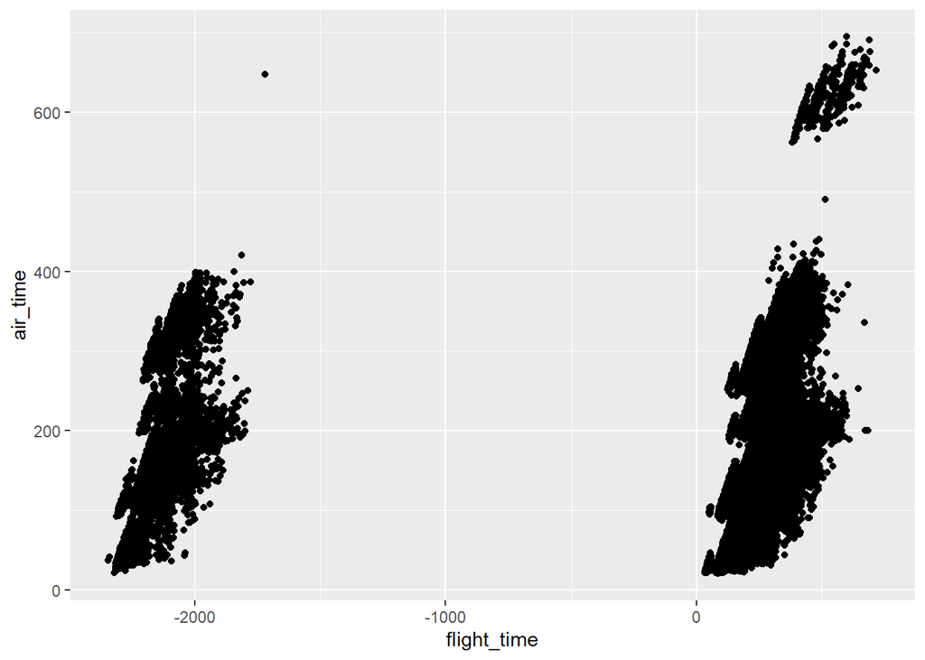

```r
# new variable flight time in not_canceled
flights_time <- mutate(not_canceled, flight_time = arr_time - dep_time)

# plot the data with x = flight time and y = air time
ggplot(data = flights_time) +
  geom_point(mapping = aes(x = flight_time, y = air_time))
```

2. What do you expect to see? What do you see? Why are there negative values in `flight_time`?

**ANSWER** There are negative values because if a flight arrives after midnight, i.e after 0000, the departure time will be greater than it thus giving a negative value.

3. Fix your R code to correct the negative values in `flight_time`. Make the scatter plot again.

**Hint:** The `lubridate` package would be helpful. Check out our textbook **[Chapter 16 “Dates and times”](http://r4ds.had.co.nz/dates-and-times.html)**

```r
library(lubridate)
flights_time <- mutate(flights_time,
                       new_arr_time = make_datetime(year, month, day, arr_time%/%100, arr_time%%100),
                       new_dep_time = make_datetime(year, month, day, dep_time%/%100, dep_time%%100),
                       new_flight_time = new_arr_time - new_dep_time)
flights_time
```

```
## # A tibble: 327,346 x 23
##     year month   day dep_time sched_dep_time dep_delay arr_time sched_arr_time
##    <int> <int> <int>    <int>          <int>     <dbl>    <int>          <int>
##  1  2013     1     1      517            515         2      830            819
##  2  2013     1     1      533            529         4      850            830
##  3  2013     1     1      542            540         2      923            850
##  4  2013     1     1      544            545        -1     1004           1022
##  5  2013     1     1      554            600        -6      812            837
##  6  2013     1     1      554            558        -4      740            728
##  7  2013     1     1      555            600        -5      913            854
##  8  2013     1     1      557            600        -3      709            723
##  9  2013     1     1      557            600        -3      838            846
## 10  2013     1     1      558            600        -2      753            745
## # ... with 327,336 more rows, and 15 more variables: arr_delay <dbl>,
## #   carrier <chr>, flight <int>, tailnum <chr>, origin <chr>, dest <chr>,
## #   air_time <dbl>, distance <dbl>, hour <dbl>, minute <dbl>, time_hour <dttm>,
## #   flight_time <int>, new_arr_time <dttm>, new_dep_time <dttm>,
## #   new_flight_time <drtn>
```

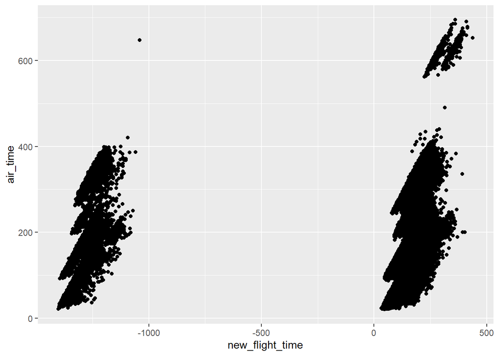

```r
for(i in 1:length(flights_time)){
  if(flights_time$new_flight_time[i] < 0){
    flights_time$new_flight_time[i] <- (flights_time$new_flight_time[i] + 60*24) * (-1)
  }
}

ggplot(data = flights_time) +
  geom_point(mapping = aes(x = new_flight_time, y = air_time))
```

### (e) **[Extra Credit 20pt]** More on date and time

You have probably wondered why your scatter plot didn’t have a clear linear relationship. The reasons were due to the time zone differences as well as the daylight saving time (DST). Modify your R code to solve these issues.

**Hint:** Check out the `nycflights13::airports` data set. You can *join* `flights` and `airports` using destination airport FAA code as the *key*.

```r
#?airports
airports %>% glimpse()
## Rows: 1,458
## Columns: 8
## $ faa   <chr> "04G", "06A", "06C", "06N", "09J", "0A9", "0G6", "0G7", "0P2"...
## $ name  <chr> "Lansdowne Airport", "Moton Field Municipal Airport", "Schaum...
## $ lat   <dbl> 41.13047, 32.46057, 41.98934, 41.43191, 31.07447, 36.37122, 4...
## $ lon   <dbl> -80.61958, -85.68003, -88.10124, -74.39156, -81.42778, -82.17...
## $ alt   <dbl> 1044, 264, 801, 523, 11, 1593, 730, 492, 1000, 108, 409, 875,...
## $ tz    <dbl> -5, -6, -6, -5, -5, -5, -5, -5, -5, -8, -5, -6, -5, -5, -5, -...
## $ dst   <chr> "A", "A", "A", "A", "A", "A", "A", "A", "U", "A", "A", "U", "...
## $ tzone <chr> "America/New_York", "America/Chicago", "America/Chicago", "Am...

left_join(flights, airports, by=c("dest"="faa")) %>% glimpse()
## Rows: 336,776
## Columns: 26
## $ year           <int> 2013, 2013, 2013, 2013, 2013, 2013, 2013, 2013, 2013...
## $ month          <int> 1, 1, 1, 1, 1, 1, 1, 1, 1, 1, 1, 1, 1, 1, 1, 1, 1, 1...
## $ day            <int> 1, 1, 1, 1, 1, 1, 1, 1, 1, 1, 1, 1, 1, 1, 1, 1, 1, 1...
## $ dep_time       <int> 517, 533, 542, 544, 554, 554, 555, 557, 557, 558, 55...
## $ sched_dep_time <int> 515, 529, 540, 545, 600, 558, 600, 600, 600, 600, 60...
## $ dep_delay      <dbl> 2, 4, 2, -1, -6, -4, -5, -3, -3, -2, -2, -2, -2, -2,...
## $ arr_time       <int> 830, 850, 923, 1004, 812, 740, 913, 709, 838, 753, 8...
## $ sched_arr_time <int> 819, 830, 850, 1022, 837, 728, 854, 723, 846, 745, 8...
## $ arr_delay      <dbl> 11, 20, 33, -18, -25, 12, 19, -14, -8, 8, -2, -3, 7,...
## $ carrier        <chr> "UA", "UA", "AA", "B6", "DL", "UA", "B6", "EV", "B6"...
## $ flight         <int> 1545, 1714, 1141, 725, 461, 1696, 507, 5708, 79, 301...
## $ tailnum        <chr> "N14228", "N24211", "N619AA", "N804JB", "N668DN", "N...
## $ origin         <chr> "EWR", "LGA", "JFK", "JFK", "LGA", "EWR", "EWR", "LG...
## $ dest           <chr> "IAH", "IAH", "MIA", "BQN", "ATL", "ORD", "FLL", "IA...
## $ air_time       <dbl> 227, 227, 160, 183, 116, 150, 158, 53, 140, 138, 149...
## $ distance       <dbl> 1400, 1416, 1089, 1576, 762, 719, 1065, 229, 944, 73...
## $ hour           <dbl> 5, 5, 5, 5, 6, 5, 6, 6, 6, 6, 6, 6, 6, 6, 6, 5, 6, 6...
## $ minute         <dbl> 15, 29, 40, 45, 0, 58, 0, 0, 0, 0, 0, 0, 0, 0, 0, 59...
## $ time_hour      <dttm> 2013-01-01 05:00:00, 2013-01-01 05:00:00, 2013-01-0...
## $ name           <chr> "George Bush Intercontinental", "George Bush Interco...
## $ lat            <dbl> 29.98443, 29.98443, 25.79325, NA, 33.63672, 41.97860...
## $ lon            <dbl> -95.34144, -95.34144, -80.29056, NA, -84.42807, -87....
## $ alt            <dbl> 97, 97, 8, NA, 1026, 668, 9, 313, 96, 668, 19, 26, 1...
## $ tz             <dbl> -6, -6, -5, NA, -5, -6, -5, -5, -5, -6, -5, -5, -8, ...
## $ dst            <chr> "A", "A", "A", NA, "A", "A", "A", "A", "A", "A", "A"...
## $ tzone          <chr> "America/Chicago", "America/Chicago", "America/New_Y...
```

### (f) [50pt] Calculate group-wise summaries - combine `summarise()` and `group_by()`

#### (f.1) [25pt] Daily flight cancellation rate

1. Suppose we are interested in studying the number of canceled flights per day. Is there a pattern? Make a scatter plot of the proportion of canceled flights per day (x-axis) vs average delay per day (y-axis). Use point size to represent the number of originally scheduled flights on each day. Add a smoothed fitted line to your scatter plot. Is the proportion of canceled flights related to the average delay?

**Hint:** Group `flights` (do not use `not_canceled`) by both month and day, so that your scatter plot has 365 points in total.

**ANSWER**

```r
canceled <-
  flights %>%
  group_by(month, day) %>%
  summarise(count = n(),
            canceled_flights = sum(is.na(dep_delay)),
            canceled_proportion = canceled_flights/count,
            avg_delay = mean(arr_delay, na.rm = T))
canceled
```

```
## # A tibble: 365 x 6
## # Groups:   month [12]
##    month   day count canceled_flights canceled_proportion avg_delay
##    <int> <int> <int>            <int>               <dbl>     <dbl>
##  1     1     1   842                4             0.00475    12.7
##  2     1     2   943                8             0.00848    12.7
##  3     1     3   914               10             0.0109      5.73
##  4     1     4   915                6             0.00656    -1.93
##  5     1     5   720                3             0.00417    -1.53
##  6     1     6   832                1             0.00120     4.24
##  7     1     7   933                3             0.00322    -4.95
##  8     1     8   899                4             0.00445    -3.23
##  9     1     9   902                5             0.00554    -0.264
## 10     1    10   932                3             0.00322    -5.90
## # ... with 355 more rows
```

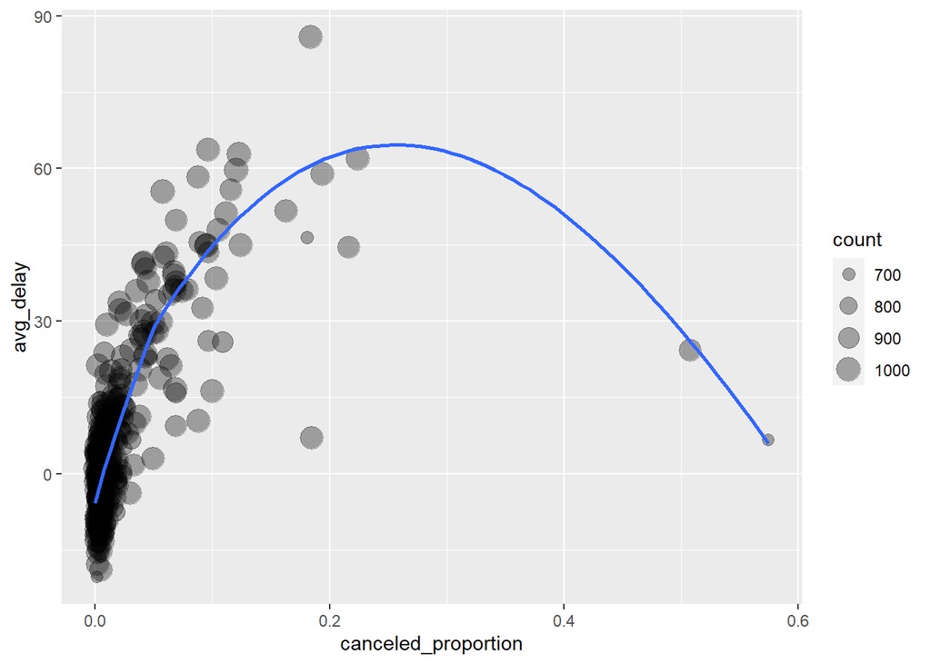

```r
ggplot( data = canceled, mapping = aes(x = canceled_proportion, y = avg_delay)) +
  geom_point(mapping = aes(size = count), alpha = 1/3) +
  geom_smooth(se = F)
```

2. Which two days had the highest flight cancellation rates?

**ANSWER**

```r
# arrange canceled flights by proportion
arrange(canceled, desc(canceled_proportion))
```

```
## # A tibble: 365 x 6
## # Groups:   month [12]
##    month   day count canceled_flights canceled_proportion avg_delay
##    <int> <int> <int>            <int>               <dbl>     <dbl>
##  1     2     9   684              393               0.575      6.64
##  2     2     8   930              472               0.508     24.2
##  3     5    23   988              221               0.224     62.0
##  4    12    10   943              204               0.216     44.5
##  5     9    12   992              192               0.194     58.9
##  6     3     6   972              180               0.185      6.97
##  7     3     8   979              180               0.184     85.9
##  8    12    14   692              125               0.181     46.4
##  9    12     5   969              158               0.163     51.7
## 10     6    28   994              123               0.124     45.0
## # ... with 355 more rows
```

```r
# The days were 2/9 and 2/8
```

3. Remove the two days with the highest flight cancellation rates and re-draw your scatter plot.

**ANSWER**

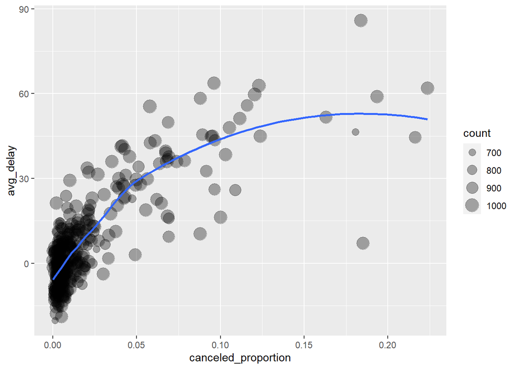

```r
# get all flights except the two highest which have a proportion greater than 0.50
lower_flights <- canceled %>%
  filter(canceled_proportion <0.50)
# plot new data
ggplot( data = lower_flights, mapping = aes(x = canceled_proportion, y = avg_delay)) +
  geom_point(mapping = aes(size = count), alpha = 1/3) +
  geom_smooth(se = F)
```

4. What do you think might be the main reason for these two high cancellation rates? Find out supporting evidences from the `nycfights13::weather` data set.

```r
#?weather
weather %>% glimpse()
## Rows: 26,115
## Columns: 15
## $ origin     <chr> "EWR", "EWR", "EWR", "EWR", "EWR", "EWR", "EWR", "EWR", ...
## $ year       <int> 2013, 2013, 2013, 2013, 2013, 2013, 2013, 2013, 2013, 20...
## $ month      <int> 1, 1, 1, 1, 1, 1, 1, 1, 1, 1, 1, 1, 1, 1, 1, 1, 1, 1, 1,...
## $ day        <int> 1, 1, 1, 1, 1, 1, 1, 1, 1, 1, 1, 1, 1, 1, 1, 1, 1, 1, 1,...
## $ hour       <int> 1, 2, 3, 4, 5, 6, 7, 8, 9, 10, 11, 13, 14, 15, 16, 17, 1...
## $ temp       <dbl> 39.02, 39.02, 39.02, 39.92, 39.02, 37.94, 39.02, 39.92, ...
## $ dewp       <dbl> 26.06, 26.96, 28.04, 28.04, 28.04, 28.04, 28.04, 28.04, ...
## $ humid      <dbl> 59.37, 61.63, 64.43, 62.21, 64.43, 67.21, 64.43, 62.21, ...
## $ wind_dir   <dbl> 270, 250, 240, 250, 260, 240, 240, 250, 260, 260, 260, 3...
## $ wind_speed <dbl> 10.35702, 8.05546, 11.50780, 12.65858, 12.65858, 11.5078...
## $ wind_gust  <dbl> NA, NA, NA, NA, NA, NA, NA, NA, NA, NA, NA, NA, NA, NA, ...
## $ precip     <dbl> 0, 0, 0, 0, 0, 0, 0, 0, 0, 0, 0, 0, 0, 0, 0, 0, 0, 0, 0,...
## $ pressure   <dbl> 1012.0, 1012.3, 1012.5, 1012.2, 1011.9, 1012.4, 1012.2, ...
## $ visib      <dbl> 10, 10, 10, 10, 10, 10, 10, 10, 10, 10, 10, 10, 10, 10, ...
## $ time_hour  <dttm> 2013-01-01 01:00:00, 2013-01-01 02:00:00, 2013-01-01 03...
```

#### (f.2) [25pt] Best/worst carrier of the year

1. Suppose we are interested in identifying the carriers with the least/worst delays. To disentangle the effects of bad airports vs. bad carriers, we group all **non-canceled** flights by both carrier and dest, then calculate the average arrival delay for each carrier and dest pair. Make side-by-side boxplots to compare the distribution of average arrival delay among different carriers. Flip your boxplot to have horizontal display and rank all boxes by their median values.

**ANSWER**

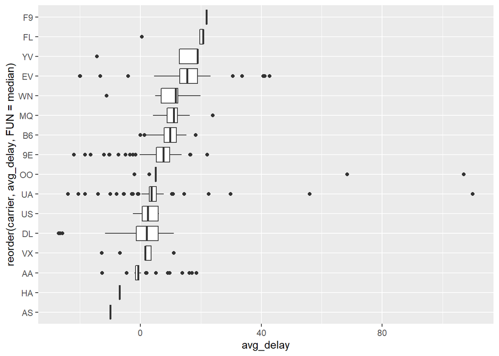

```r
# group by carrier and destination then calculate mean delay
not_canceled <-
  not_canceled %>%
  group_by(carrier, dest) %>%
  mutate(avg_delay = mean(arr_delay))
# splot data using median to find the least/worst average delay
ggplot(data = not_canceled) +
  geom_boxplot(mapping = aes(x = reorder(carrier, avg_delay, FUN = median), y = avg_delay)) +
  coord_flip()
```

2. Which carrier had the least delays? Which carrier had the worst delays?

**ANSWER** It looks like the carrier with the worst delays was F9 and the carrier with the least delays was AS.

3. Is there a small `n` problem in your data analysis? Count the number of destinations per carrier.

**Hint:** Check out the `count()` function @ https://dplyr.tidyverse.org/reference/tally.html

**ANSWER**

```r
# count the number of destinations by carrier and destination
not_canceled %>%
  count(carrier, dest)
```

```
## # A tibble: 312 x 3
## # Groups:   carrier, dest [312]
##    carrier dest      n
##    <chr>   <chr> <int>
##  1 9E      ATL      56
##  2 9E      AUS       2
##  3 9E      AVL      10
##  4 9E      BNA     452
##  5 9E      BOS     853
##  6 9E      BTV       2
##  7 9E      BUF     789
##  8 9E      BWI     815
##  9 9E      CAE       3
## 10 9E      CHS     331
## # ... with 302 more rows
```

4. Remove the carriers that only flew to one destination. Re-draw your boxplot and re-name the best/worst carriers.

**ANSWER**

```r
# find the carriers that only flew to one destination
not_canceled %>%
  count(carrier, dest) %>%
  group_by(carrier) %>%
  filter(n == 1)
```

```
## # A tibble: 15 x 3
## # Groups:   carrier [6]
##    carrier dest      n
##    <chr>   <chr> <int>
##  1 9E      GSO       1
##  2 9E      LEX       1
##  3 9E      MSN       1
##  4 DL      BNA       1
##  5 DL      JAX       1
##  6 DL      OMA       1
##  7 DL      STL       1
##  8 EV      TPA       1
##  9 OO      IAD       1
## 10 OO      ORD       1
## 11 UA      CHS       1
## 12 UA      DTW       1
## 13 UA      IAD       1
## 14 UA      RDU       1
## 15 VX      SJC       1
```

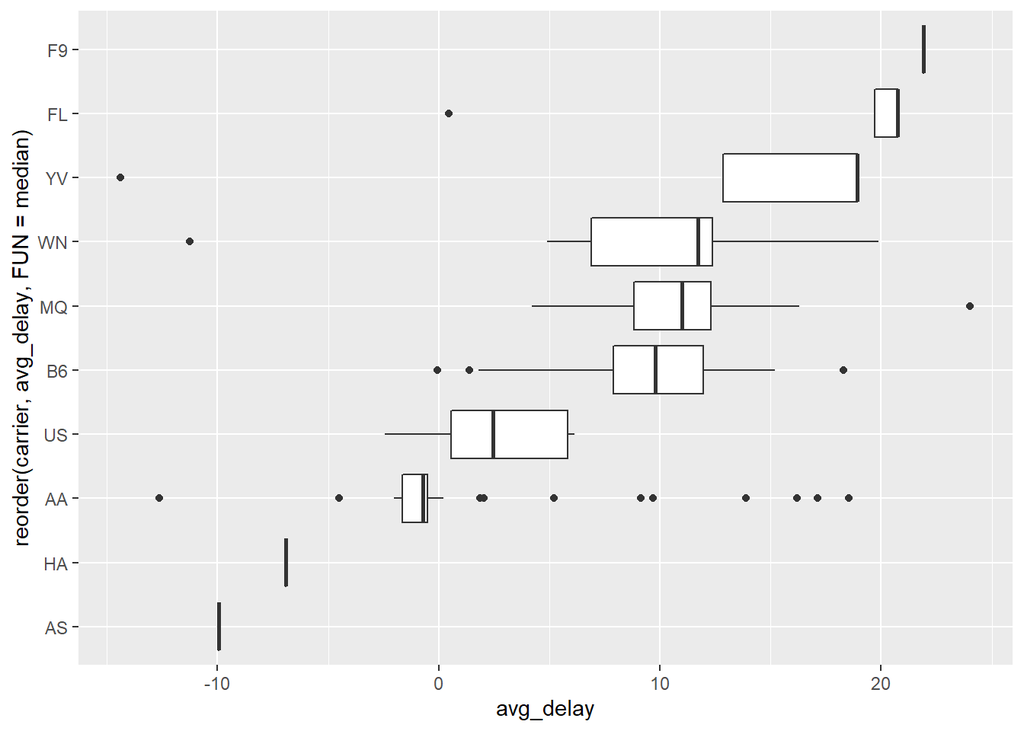

```r
# recalculate the new avg mean filtering out carriers with n = 1
not_canceled_tally <- not_canceled %>%
  filter(carrier != "9E", carrier != "DL", carrier != "EV", carrier != "OO", carrier !="UA", carrier !="VX") %>%
  mutate(avg_delay = mean(arr_delay))

#plot new graph with new data
ggplot(data = not_canceled_tally) +
  geom_boxplot(mapping = aes(x = reorder(carrier, avg_delay, FUN = median), y = avg_delay)) +
  coord_flip()
```